# Introduction

19025

2020/1/1

## Overview

**SC19025** is a simple R package including all my homework and two new functions for nonparametric hypothesis testing(the tests for independence and symmetry). Next I will show these functions.

## Independence and symmetry testing by nonparametric methods

I will illustrate the usage of the two functions you implemented by several examples.

For the independence test. The two elements in data faithful are dependent.

```r
library(SC19025)
d1<-faithful$eruptions
d2<-faithful$waiting
Test<-independence(d1,d2,0.05)
Test
```

```
## $p
## [1] 0
##
## $T
## [1] FALSE
```

We can see that the test shows that the two data vectors are dependent.

For the symmetry test.

```r
d1<-rnorm(100)
d2<-rnorm(100,mean=0.5)
Test1<-symmetry(d1,0.05)
Test1
```

```
## $p
## [1] 0.2710267
##
## $T
## [1] TRUE
```

```r
Test2<-symmetry(d2,0.05)
Test2
```

```
## $p
## [1] 0.04534539
##
## $T
## [1] FALSE
```

We can see that for the symmetric distribution(Normal) and the asymmetric distribution(Normal with mean=0.5),this test made the right judgment.

## homework

homework-2019-9-27

1

```r
n <- 1e4
y <- numeric(n)
k<-0
i<-0
c<-4*exp(1)/3
while(k<n){
  u<-runif(1)
  V<-runif(1)
  g<-2*log(3/(2*V))/3
  if(c*u*3/2*exp(-3/2*g)<g*exp(-g*g/2)){
    k<-k+1
    y[k]<-g
  }
  i<-i+1
}

i
```

```
## [1] 25080
```

```r
mean(y)
```

```
## [1] 1.287148
```

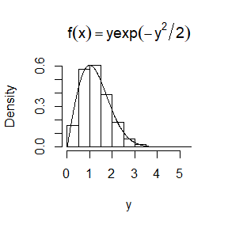

```r
hist(y, prob = TRUE, main = expression(f(x)==y*exp(-y^2/2)))
x<-seq(0,4,.01)
lines(x,x*exp(-x*x/2))
```

2

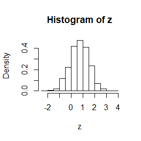

```r
x<-rnorm(1000)
y<-rnorm(1000,mean=3)
p<-0.75
z<-p*x+(1-p)*y
hist(z, prob = TRUE)
```

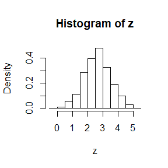

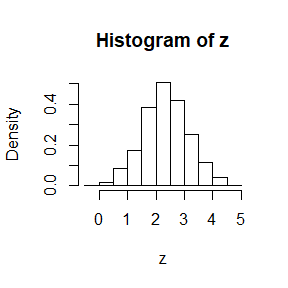

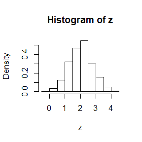

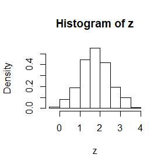

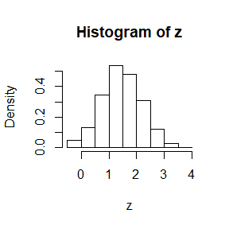

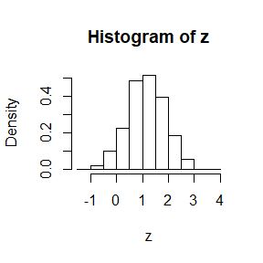

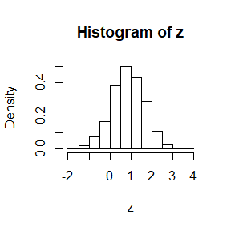

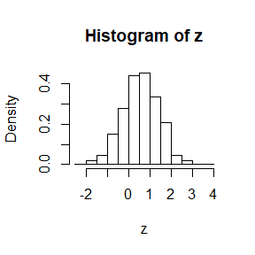

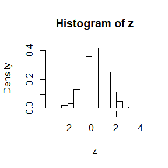

```r
p<-seq(0.1,0.9,.1)
z<-numeric(11)
for(i in 1:9){
  z<-p[i]*x+(1-p[i])*y
  hist(z, prob = TRUE)
}
```

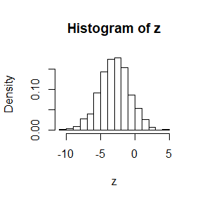

```r
p<-2
z<-p*x+(1-p)*y
hist(z, prob = TRUE)
```

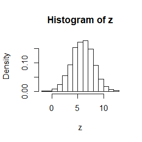

```r
p<--1
z<-p*x+(1-p)*y
hist(z, prob = TRUE)
```

3

```r
d<-5
n<-10
sigma<-matrix(nrow=d,ncol=d)
for(i in 1:d){
  for(j in 1:d)

      sigma[i,j]<-min(i/j,j/i)
}
sigma
```

```
##           [,1]      [,2]      [,3] [,4] [,5]
## [1,] 1.0000000 0.5000000 0.3333333 0.25  0.2
## [2,] 0.5000000 1.0000000 0.6666667 0.50  0.4
## [3,] 0.3333333 0.6666667 1.0000000 0.75  0.6
## [4,] 0.2500000 0.5000000 0.7500000 1.00  0.8
## [5,] 0.2000000 0.4000000 0.6000000 0.80  1.0
```

```r
c<-eigen(sigma, symmetric = TRUE)$vectors
c
```

```
##            [,1]        [,2]       [,3]       [,4]        [,5]
## [1,] -0.2939486  0.75103485 -0.5681338  0.1627713  0.01644255
## [2,] -0.4441167  0.37945919  0.5646254 -0.5694691 -0.12519655
## [3,] -0.5055511 -0.05775703  0.3803032  0.6367788  0.43699484
## [4,] -0.5029449 -0.33601038 -0.1534658  0.1831816 -0.75962899
## [5,] -0.4558718 -0.41918794 -0.4361650 -0.4584406  0.46481692
```

```r
S<-matrix(0,nrow=d,ncol=d)
for(i in 1:n){
  x<-rnorm(d)
  y<-c%*%x
  S<-S+y%*%t(y)
}
S
```

```
##             [,1]       [,2]       [,3]        [,4]       [,5]
## [1,] 13.02697027  3.0268927 -0.8686010  0.01959534  6.6268033
## [2,]  3.02689267  8.5282086 -0.8371334 -0.79577646  0.7271552
## [3,] -0.86860104 -0.8371334  3.8528476 -0.34358512 -0.6496934
## [4,]  0.01959534 -0.7957765 -0.3435851  9.33335857 -2.6055515
## [5,]  6.62680330  0.7271552 -0.6496934 -2.60555145  7.8550026
```

homework-2019-10-11

1

```r
m <- 1e3
x<-runif(m,min=0,max=pi/3)
pihat <-mean(sin(x))*pi/3
pihat
```

```
## [1] 0.4965217
```

```r
abs(0.5-pihat)
```

```
## [1] 0.003478291
```

```r
m <- 1e4
x<-runif(m,min=0,max=pi/3)
pihat <-mean(sin(x))*pi/3
pihat
```

```
## [1] 0.4970678
```

```r
abs(0.5-pihat)
```

```
## [1] 0.002932237
```

```r
m <- 1e5
x<-runif(m,min=0,max=pi/3)
pihat <-mean(sin(x))*pi/3
pihat
```

```
## [1] 0.5004706
```

```r
abs(0.5-pihat)
```

```
## [1] 0.0004706217
```

```r
m <- 1e6
x<-runif(m,min=0,max=pi/3)
pihat <-mean(sin(x))*pi/3
pihat
```

```
## [1] 0.4995589
```

```r
abs(0.5-pihat)
```

```
## [1] 0.0004410809
```

2

```r
n<-1e3
integrate(function(aa) exp(-aa)/(1+aa^2),0,1)
```

```
## 0.5247971 with absolute error < 5.8e-15
```

```r
x<-runif(n)
y<-exp(-x)/(1+x^2)
z<-(exp(-x)/(1+x^2)+exp(x-1)/(1+(1-x)^2))*0.5
y2<-exp(x-1)/(1+(1-x)^2)
mean(y)
```

```
## [1] 0.5330626
```

```r
mean(y2)
```

```
## [1] 0.5145796
```

```r
mean(z)
```

```
## [1] 0.5238211
```

```r
cov(y,y2)
```

```
## [1] -0.05633394
```

```r
var(y)
```

```
## [1] 0.05872164
```

```r
var(y2)
```

```
## [1] 0.05827469
```

```r
var(z)
```

```
## [1] 0.001082114
```

```r
var(z)/var(y)
```

```
## [1] 0.01842786
```

3

```r
M <- 10000
k <- 5
N<-M/k
n<-50
Y<-numeric(M)
for(j in 1:k){
  for(i in 1:N){
    u<-runif(1)
    x <- - log(1-(1-exp(-1))*(j-1-u)/5)
    Y[i+(j-1)*N]<-(1-exp(-1))/(1+x^2)
  }
}
mean(Y)
```

```
## [1] 0.5762625
```

```r
sd(Y)
```

```
## [1] 0.06246941
```

```r
Y1<-numeric(100)
Y2<-numeric(100)
for(l in 1:100){
for(j in 1:k){
  for(i in 1:N){
    u<-runif(1,min=(j-1)*0.2,max=j*0.2)
    x <- - log(1 - u * (1 - exp(-1)))
    Y[i+(j-1)*N]<-(1-exp(-1))/(1+x^2)
  }
}
Y1[l]<-mean(Y)
u<-runif(M)
x <- - log(1 - u * (1 - exp(-1)))
Y2[l]<-mean((1-exp(-1))/(1+x^2))
}
sd(Y1)
```

```
## [1] 0.000194224
```

```r
sd(Y2)
```

```
## [1] 0.001008692
```

homework-2019-10-18

1

```r
n <- 20   # example6.4的算法
alpha <- .05
p<-numeric(10000)
for( i in 1:10000){
x <- rnorm(n, mean=0, sd=2)
UCL <- (n-1) * var(x) / qchisq(alpha, df=n-1)
if (UCL>4){
  p[i]=1
}
else{
  p[i]=0
}
}
mean(p)
```

```
## [1] 0.9522
```

```r
n<-20
alpha<-0.05
p<-numeric(10000)  # t区间的覆盖概率
q<-numeric(10000)  #对同样样本计算方差置信区间的覆盖概率
for(i in 1:10000){
  x <- rnorm(n, mean=0, sd=1)
  y <- rnorm(n, mean=0, sd=1)
  z<-x^2+y^2     #n=2的卡方分布
  min<-mean(z)+sd(z)*qt(alpha/2,n-1)
  max<-mean(z)+sd(z)*qt(1-alpha/2,n-1)
  if(min<2&max>2){
    p[i]=1
  }
  else{
    p[i]=0
  }
  UCL <- (n-1) * var(z) / qchisq(alpha, df=n-1)
  if(UCL>4){
    q[i]=1
  }
  else{
    q[i]=0
  }
}
mean(p)
```

```
## [1] 1
```

```r
mean(q)
```

```
## [1] 0.7906
```

2

```r
n<-100             #样本数量
m<-100             #每个样本的数据个数
alpha1<-0.025
alpha2<-0.05
alpha3<-0.95
alpha4<-0.975
b<-numeric(n)
for(i in 1:n){
  x<-rnorm(m)
  b[i]=sum((x-mean(x))^3)/(var(x))^(3/2)/m
}
mean(b)             #1000个样本偏度均值
```

```
## [1] 0.03296333
```

```r
var(b)              #1000个样本偏度方差
```

```
## [1] 0.0484707
```

```r
q1<-quantile(b,alpha1)
q2<-quantile(b,alpha2)
q3<-quantile(b,alpha3)
q4<-quantile(b,alpha4)
c(q1,q2,q3,q4)          #蒙特卡洛分位数
```

```
##       2.5%         5%        95%      97.5%
## -0.4396182 -0.3678476  0.3791719  0.4176691
```

```r
f<-function(x){exp(-(x-mean(b))^2/(2*var(b)))/((2*pi*var(b))^0.5)}      #近似的正态密度函数
sd1<-(alpha1*(1-alpha1)/n/f(q1)^2)^0.5
sd2<-(alpha2*(1-alpha2)/n/f(q2)^2)^0.5
sd3<-(alpha3*(1-alpha3)/n/f(q3)^2)^0.5
sd4<-(alpha4*(1-alpha4)/n/f(q4)^2)^0.5
c(sd1,sd2,sd3,sd4)                          #偏度分位数的方差
```

```
##       2.5%         5%        95%      97.5%
## 0.08626373 0.06307841 0.04141401 0.03965800
```

```r
p1<-qnorm(alpha1,mean=0,sd=(6/m)^0.5)
p2<-qnorm(alpha2,mean=0,sd=(6/m)^0.5)
p3<-qnorm(alpha3,mean=0,sd=(6/m)^0.5)
p4<-qnorm(alpha4,mean=0,sd=(6/m)^0.5)
c(p1,p2,p3,p4)                              #大样本偏度的分位数
```

```
## [1] -0.4800912 -0.4029052  0.4029052  0.4800912
```

```r
c(abs((q1-p1)/p1),abs((q2-p2)/p2),abs((q3-p3)/p3),abs((q4-p4)/p4))         #蒙特卡洛偏度分位数雨大样本分位数的误差比
```

```
##       2.5%         5%        95%      97.5%
## 0.08430269 0.08701207 0.05890538 0.13002128
```

homework-2019-11-01

1

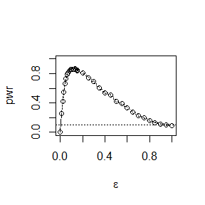

```r
alpha <- .1                      #显著性
alpha1<-1                        #beta分布的alpha参数值
n <- 30
m <- 2500
epsilon <- c(seq(0, .15, .01), seq(.15, 1, .05))     #不同epslion值
N <- length(epsilon)
pwr <- numeric(N)
cv <- qnorm(1-alpha/2, 0, sqrt(6*(n-2) / ((n+1)*(n+3))))
for (j in 1:N) {
e <- epsilon[j]
sktests <- numeric(m)
for (i in 1:m) {
x<-numeric(n)
for(k in 1:n){                           #生成样本
  u<-runif(1)
  if(u>epsilon[j]){
    x[k]<-rbeta(1,shape1 =alpha1,shape2 = alpha1)
  }
  else{
    x[k]<-rnorm(1,mean=0.5,sd=10)              #beta分布的均值为0.5
  }
}
sk<-sum((x-mean(x))^3)/n/(var(x))^1.5
sktests[i] <- as.integer(abs(sk) >= cv)         #峰度检验
}
pwr[j] <- mean(sktests)
}
#plot power vs epsilon
plot(epsilon, pwr, type = "b",
xlab = bquote(epsilon), ylim = c(0,1))
abline(h = .1, lty = 3)
se <- sqrt(pwr * (1-pwr) / m) #add standard errors
lines(epsilon, pwr+se, lty = 3)
lines(epsilon, pwr-se, lty = 3)
```

2

```r
alpha<-0.05        #两样本t检验
p1<-0.651
p2<-0.676
p<-0
n<-10000
ttest<-(p1-p2)/((p1*(1-p1)+p2*(1-p2))/n)^0.5
if(ttest<qt(alpha/2,df=2*n-2)|ttest>qt(1-alpha/2,df=2*n-2)){
    p<-1
}
p
```

```
## [1] 1
```

```r
sigma<-(p1-p2)*sqrt(n)/qnorm(alpha/2)          #z检验给定方差的临界值
sigma
```

```
## [1] 1.275534
```

```r
p<-sqrt((p1-p2)^2+n*(p1-p2)^2/(qt(alpha/2,df=n-1))^2)*n      #配对t检验差值不为0个数的临界值
p
```

```
## [1] 12756.24
```

homework-2019-11-08

1

```r
library(bootstrap)
```

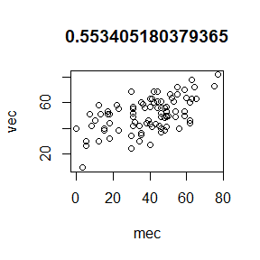

```r
mec<-scor$mec
vec<-scor$vec
alg<-scor$alg
ana<-scor$ana
sta<-scor$sta
plot(mec,vec,main=cov(mec,vec)/sqrt(var(mec))/sqrt(var(vec)))               #作每一对成绩的散点图，标题为二者相关系数
```

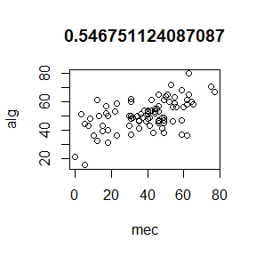

```r
plot(mec,alg,main=cov(mec,alg)/sqrt(var(mec))/sqrt(var(alg)))
```

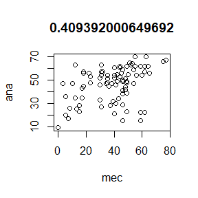

```r
plot(mec,ana,main=cov(mec,ana)/sqrt(var(mec))/sqrt(var(ana)))
```

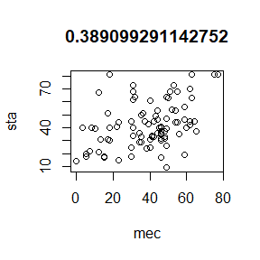

```r
plot(mec,sta,main=cov(mec,sta)/sqrt(var(mec))/sqrt(var(sta)))
```

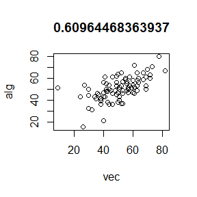

```r
plot(vec,alg,main=cov(vec,alg)/sqrt(var(vec))/sqrt(var(alg)))
```

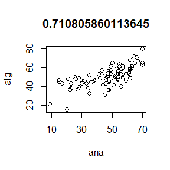

```r
plot(ana,alg,main=cov(ana,alg)/sqrt(var(ana))/sqrt(var(alg)))
```

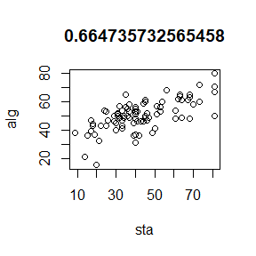

```r
plot(sta,alg,main=cov(sta,alg)/sqrt(var(sta))/sqrt(var(alg)))
```

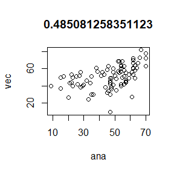

```r
plot(ana,vec,main=cov(ana,vec)/sqrt(var(ana))/sqrt(var(vec)))
```

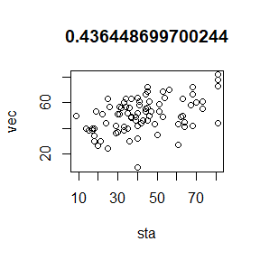

```r
plot(sta,vec,main=cov(sta,vec)/sqrt(var(sta))/sqrt(var(vec)))
```

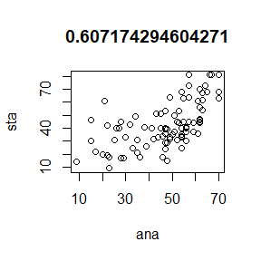

```r
plot(ana,sta,main=cov(ana,sta)/sqrt(var(ana))/sqrt(var(sta)))
```

```r
B<-200
n<-length(mec)
rho45<-rho35<-rho34<-rho12<-numeric(B)
mecb<-vecb<-algb<-anab<-stab<-numeric(n)
for(i in 1:B){                                                     #bootstrap估计
  rd1<-sample(1:n,n,replace=T)
  for(j in 1:n){
    mecb[j]<-mec[rd1[j]]
    vecb[j]<-vec[rd1[j]]
  }
  rho12[i]<-cov(mecb,vecb)/sqrt(var(mecb))/sqrt(var(vecb))
  rd2<-sample(1:n,n,replace=T)
  for(j in 1:n){
    algb[j]<-alg[rd2[j]]
    anab[j]<-ana[rd2[j]]
  }
  rho34[i]<-cov(algb,anab)/sqrt(var(algb))/sqrt(var(anab))
  rd3<-sample(1:n,n,replace=T)
  for(j in 1:n){
    algb[j]<-alg[rd3[j]]
    stab[j]<-sta[rd3[j]]
  }
  rho35[i]<-cov(algb,stab)/sqrt(var(algb))/sqrt(var(stab))
  rd4<-sample(1:n,n,replace=T)
  for(j in 1:n){
    stab[j]<-sta[rd4[j]]
    anab[j]<-ana[rd4[j]]
  }
  rho45[i]<-cov(stab,anab)/sqrt(var(stab))/sqrt(var(anab))
}
m1<-mean(rho12)
m2<-mean(rho34)
m3<-mean(rho35)
m4<-mean(rho45)
c("rho12","rho34","rho35","rho45")
```

```
## [1] "rho12" "rho34" "rho35" "rho45"
```

```r
c(mean(rho12),mean(rho34),mean(rho35),mean(rho45))                #bootstrap相关系数估计值
```

```
## [1] 0.5547512 0.7124127 0.6654385 0.6055135
```

```r
c(cov(mec,vec)/sqrt(var(mec))/sqrt(var(vec)),cov(ana,alg)/sqrt(var(ana))/sqrt(var(alg)),cov(sta,alg)/sqrt(var(sta))/sqrt(var(alg)),cov(ana,sta)/sqrt(var(ana))/sqrt(var(sta)))         #实际数据相关系数
```

```
## [1] 0.5534052 0.7108059 0.6647357 0.6071743
```

```r
var1<-var2<-var3<-var4<-0
for(i in 1:B){
  var1<-var1+(rho12[i]-m1)^2/(B-1)
  var2<-var2+(rho34[i]-m1)^2/(B-1)
  var3<-var3+(rho35[i]-m1)^2/(B-1)
  var4<-var4+(rho45[i]-m1)^2/(B-1)
}
c(sqrt(var1),sqrt(var2),sqrt(var3),sqrt(var4))                    #bootstrap估计标准差
```

```
## [1] 0.07246144 0.16534000 0.12369268 0.08456777
```

2

```r
alpha<-0.1                                         #置信区间的水平
m<-1000                                            #模拟次数
n<-50                                              #每次选取样本数
B<-200                                             #bootstrap循环次数
p1ln<-p1rn<-p2ln<-p2rn<-p1n<-p2n<-0
p1lb<-p1rb<-p2lb<-p2rb<-p1b<-p2b<-0
p1lp<-p1rp<-p2lp<-p2rp<-p1p<-p2p<-0                #分别记录两种分布，三种置信区间左右和总偏离概率
for(i in 1:m){
  skc<-skn<-numeric(B)
  no<-rnorm(n)
  ch<-rchisq(n,df=5)
  nob<-chb<-numeric(n)
  for(j in 1:B){                                  #bootstrap偏度估计
    x<-sample(1:n,n,replace=T)
    for(k in 1:n){
      nob[k]<-no[x[k]]
      chb[k]<-ch[x[k]]
    }
    skn[j]<-sum((nob-mean(nob))^3)/n/var(nob)^1.5
    skc[j]<-sum((chb-mean(chb))^3)/n/var(chb)^1.5
  }
  sk1<-0
  sk2<-1.6^0.5                                      #实际偏度
  norm1l<-mean(skn)+qnorm(alpha/2)*sqrt(var(skn))   #各种方法置信区间左右端点值
  norm1r<-mean(skn)-qnorm(alpha/2)*sqrt(var(skn))
  perc1l<-quantile(skn,probs=alpha/2)
  perc1r<-quantile(skn,probs=1-alpha/2)
  basic1l<-2*mean(skn)-quantile(skn,probs=1-alpha/2)
  basic1r<-2*mean(skn)-quantile(skn,probs=alpha/2)
  norm2l<-mean(skc)+qnorm(alpha/2)*sqrt(var(skc))
  norm2r<-mean(skc)-qnorm(alpha/2)*sqrt(var(skc))
  perc2l<-quantile(skc,probs=alpha/2)
  perc2r<-quantile(skc,probs=1-alpha/2)
  basic2l<-2*mean(skc)-quantile(skc,probs=1-alpha/2)
  basic2r<-2*mean(skc)-quantile(skc,probs=alpha/2)
  if(sk1<norm1l){                                   #对每次求出的置信区间分类
    p1ln=p1ln+1/m
    p1n=p1n+1/m
  }
  else if(sk1>norm1r){
    p1rn=p1rn+1/m
    p1n=p1n+1/m
  }
  if(sk1<perc1l){
    p1lp=p1lp+1/m
    p1p=p1p+1/m
  }
  else if(sk1>perc1r){
    p1rp=p1rp+1/m
    p1p=p1p+1/m
  }
  if(sk1<basic1l){
    p1lb=p1lb+1/m
    p1b=p1b+1/m
  }
  else if(sk1>basic1r){
    p1rb=p1rb+1/m
    p1b=p1b+1/m
  }
  if(sk2<norm2l){
    p2ln=p2ln+1/m
    p2n=p2n+1/m
  }
  else if(sk2>norm2r){
    p2rn=p2rn+1/m
    p2n=p2n+1/m
  }
  if(sk2<perc2l){
    p2lp=p2lp+1/m
    p2p=p2p+1/m
  }
  else if(sk2>perc2r){
    p2rp=p2rp+1/m
    p2p=p2p+1/m
  }
  if(sk2<basic2l){
    p2lb=p2lb+1/m
    p2b=p2b+1/m
  }
  else if(sk2>basic2r){
    p2rb=p2rb+1/m
    p2b=p2b+1/m
  }
}
c(p1n,p1b,p1p)                               #正态样本三种90%置信区间不包含真实偏度的比例
```

```
## [1] 0.101 0.115 0.116
```

```r
c(p1ln,p1lb,p1lp)                            #正态样本三种90%置信区间右偏于真实偏度的比例
```

```
## [1] 0.054 0.060 0.061
```

```r
c(p1rn,p1rb,p1rp)                            #正态样本三种90%置信区间左偏于真实偏度的比例
```

```
## [1] 0.047 0.055 0.055
```

```r
c(p2n,p2b,p2p)                               #卡方样本三种90%置信区间不包含真实偏度的比例
```

```
## [1] 0.382 0.392 0.393
```

```r
c(p2ln,p2lb,p2lp)                            #卡方样本三种90%置信区间右偏于真实偏度的比例
```

```
## [1] 0.001 0.001 0.001
```

```r
c(p2rn,p2rb,p2rp)                            #卡方样本三种90%置信区间左偏于真实偏度的比例
```

```
## [1] 0.381 0.391 0.392
```

```r
alpha<-0.05                                        #置信区间的水平
m<-1000                                            #模拟次数
n<-50                                              #每次选取样本数
B<-200                                             #bootstrap循环次数
p1ln<-p1rn<-p2ln<-p2rn<-p1n<-p2n<-0
p1lb<-p1rb<-p2lb<-p2rb<-p1b<-p2b<-0
p1lp<-p1rp<-p2lp<-p2rp<-p1p<-p2p<-0                #分别记录两种分布，三种置信区间左右和总偏离概率
for(i in 1:m){
  skc<-skn<-numeric(B)
  no<-rnorm(n)
  ch<-rchisq(n,df=5)
  nob<-chb<-numeric(n)
  for(j in 1:B){                                  #bootstrap偏度估计
    x<-sample(1:n,n,replace=T)
    for(k in 1:n){
      nob[k]<-no[x[k]]
      chb[k]<-ch[x[k]]
    }
    skn[j]<-sum((nob-mean(nob))^3)/n/var(nob)^1.5
    skc[j]<-sum((chb-mean(chb))^3)/n/var(chb)^1.5
  }
  sk1<-0
  sk2<-1.6^0.5                                      #实际偏度
  norm1l<-mean(skn)+qnorm(alpha/2)*sqrt(var(skn))   #各种方法置信区间左右端点值
  norm1r<-mean(skn)-qnorm(alpha/2)*sqrt(var(skn))
  perc1l<-quantile(skn,probs=alpha/2)
  perc1r<-quantile(skn,probs=1-alpha/2)
  basic1l<-2*mean(skn)-quantile(skn,probs=1-alpha/2)
  basic1r<-2*mean(skn)-quantile(skn,probs=alpha/2)
  norm2l<-mean(skc)+qnorm(alpha/2)*sqrt(var(skc))
  norm2r<-mean(skc)-qnorm(alpha/2)*sqrt(var(skc))
  perc2l<-quantile(skc,probs=alpha/2)
  perc2r<-quantile(skc,probs=1-alpha/2)
  basic2l<-2*mean(skc)-quantile(skc,probs=1-alpha/2)
  basic2r<-2*mean(skc)-quantile(skc,probs=alpha/2)
  if(sk1<norm1l){                                   #对每次求出的置信区间分类
    p1ln=p1ln+1/m
    p1n=p1n+1/m
  }
  else if(sk1>norm1r){
    p1rn=p1rn+1/m
    p1n=p1n+1/m
  }
  if(sk1<perc1l){
    p1lp=p1lp+1/m
    p1p=p1p+1/m
  }
  else if(sk1>perc1r){
    p1rp=p1rp+1/m
    p1p=p1p+1/m
  }
  if(sk1<basic1l){
    p1lb=p1lb+1/m
    p1b=p1b+1/m
  }
  else if(sk1>basic1r){
    p1rb=p1rb+1/m
    p1b=p1b+1/m
  }
  if(sk2<norm2l){
    p2ln=p2ln+1/m
    p2n=p2n+1/m
  }
  else if(sk2>norm2r){
    p2rn=p2rn+1/m
    p2n=p2n+1/m
  }
  if(sk2<perc2l){
    p2lp=p2lp+1/m
    p2p=p2p+1/m
  }
  else if(sk2>perc2r){
    p2rp=p2rp+1/m
    p2p=p2p+1/m
  }
  if(sk2<basic2l){
    p2lb=p2lb+1/m
    p2b=p2b+1/m
  }
  else if(sk2>basic2r){
    p2rb=p2rb+1/m
    p2b=p2b+1/m
  }
}
c(p1n,p1b,p1p)                               #正态样本三种90%置信区间不包含真实偏度的比例
```

```
## [1] 0.067 0.084 0.076
```

```r
c(p1ln,p1lb,p1lp)                            #正态样本三种90%置信区间右偏于真实偏度的比例
```

```
## [1] 0.03 0.04 0.03
```

```r
c(p1rn,p1rb,p1rp)                            #正态样本三种90%置信区间左偏于真实偏度的比例
```

```
## [1] 0.037 0.044 0.046
```

```r
c(p2n,p2b,p2p)                               #卡方样本三种90%置信区间不包含真实偏度的比例
```

```
## [1] 0.318 0.339 0.321
```

```r
c(p2ln,p2lb,p2lp)                            #卡方样本三种90%置信区间右偏于真实偏度的比例
```

```
## [1] 0 0 0
```

```r
c(p2rn,p2rb,p2rp)                            #卡方样本三种90%置信区间左偏于真实偏度的比例
```

```
## [1] 0.318 0.339 0.321
```

home-2019-11-15

1

```r
library(bootstrap)
n<-88
lambda<-eigen(cov(scor))$values
theta.hat<-lambda[1]/sum(lambda)
theta.hat                                          #原样本参数估计值
```

```
## [1] 0.619115
```

```r
theta<-numeric(n)                                  #n个去一参数估计值
for(i in 1:n){
  lambda<-eigen(cov(scor[-i,]))$values
  theta[i]<-lambda[1]/sum(lambda)
}
bias<-(n-1)*(mean(theta)-theta.hat)
theta.jack<-theta.hat-bias
se<-sqrt((n-1)*sum((theta-mean(theta))^2)/n)
theta.jack                                        #jackknife估计值
```

```
## [1] 0.6180459
```

```r
bias                                              #偏差
```

```
## [1] 0.001069139
```

```r
se                                                #标准差
```

```
## [1] 0.04955231
```

2

```r
library(DAAG)
magnetic<-ironslag$magnetic
chemical<-ironslag$chemical
n<-length(magnetic)
e1<-e2<-e3<-e4<-numeric(n)
for (i in 1:n) {
y <- magnetic[-i]
x <- chemical[-i]
J1 <- lm(y ~ x)
yhat1 <- J1$coef[1] + J1$coef[2] * chemical[i]
e1[i] <- magnetic[i] - yhat1
J2 <- lm(y ~ x + I(x^2))
yhat2 <- J2$coef[1] + J2$coef[2] * chemical[i] +
J2$coef[3] * chemical[i]^2
e2[i] <- magnetic[i] - yhat2
J3 <- lm(log(y) ~ x)
logyhat3 <- J3$coef[1] + J3$coef[2] * chemical[i]
yhat3 <- exp(logyhat3)
e3[i] <- magnetic[i] - yhat3
J4 <- lm(y ~ x+I(x^2)+I(x^3))
yhat4 <- J4$coef[1] + J4$coef[2] * chemical[i] +
J4$coef[3] * chemical[i]^2 + J4$coef[4] * chemical[i]^3
e4[i] <- magnetic[i] - yhat4
}
c(mean(e1^2), mean(e2^2), mean(e3^2), mean(e4^2))              #留一验证残差和
```

```
## [1] 19.55644 17.85248 18.44188 18.17756
```

```r
y <- magnetic
x <- chemical
J1 <- lm(y ~ x)
yhat1 <- J1$coef[1] + J1$coef[2] * chemical
e1 <- magnetic - yhat1
J2 <- lm(y ~ x + I(x^2))
yhat2 <- J2$coef[1] + J2$coef[2] * chemical +
J2$coef[3] * chemical^2
e2 <- magnetic - yhat2
J3 <- lm(log(y) ~ x)
logyhat3 <- J3$coef[1] + J3$coef[2] * chemical
yhat3 <- exp(logyhat3)
e3 <- magnetic - yhat3
J4 <- lm(y ~ x+I(x^2)+I(x^3))
yhat4 <- J4$coef[1] + J4$coef[2] * chemical +
J4$coef[3] * chemical^2 + J4$coef[4] * chemical^3
e4 <- magnetic - yhat4
c(1-mean(e1^2)/var(y), 1-mean(e2^2)/var(y), 1-mean(e3^2)/var(y), 1-mean(e4^2)/var(y))     #回归判定系数
```

```
## [1] 0.5459600 0.6007690 0.5690588 0.6061875
```

homework-2019-11-22

1

```r
R<-999
n<-100
num<-5                     #极端值个数阈值为5
T<-numeric(n)
T1<-numeric(1000)
for(i in 1:n){
  x<-rnorm(20)
  y<-rnorm(30)
  test<-numeric(R)
  for(j in 1:R){
    z<-numeric(50)
    for(k in 1:20){
      z[k]<-x[k]
    }
    for(k in 1:30){
      z[k+20]<-y[k]
    }
    z<-sample(z,50,replace=FALSE)
    for(k in 1:20){
      x[k]<-z[k]
    }
    for(k in 1:30){
      y[k]<-z[k+20]
    }
    X <- x - mean(x)
    Y <- y - mean(y)
    outx <- sum(X > max(Y)) + sum(X < min(Y))
    outy <- sum(Y > max(X)) + sum(Y < min(X))
    if(max(outx,outy)>num){
      test[j]<-1
    }
  }
  T[i]<-(1+sum(test))/(R+1)
}
mean(T)                       #使用了排列方法
```

```
## [1] 0.10611
```

```r
for(i in 1:100){
  x<-rnorm(20)
  y<-rnorm(30)
  test<-numeric(R)
  X <- x - mean(x)
  Y <- y - mean(y)
  outx <- sum(X > max(Y)) + sum(X < min(Y))
  outy <- sum(Y > max(X)) + sum(Y < min(X))
  if(max(outx,outy)>num){
      T1[i]<-1
    }

}
mean(T1)                      #未使用排列方法
```

```
## [1] 0.007
```

```r
R<-999
n<-100
num<-8                 #极端值个数阈值为8
T<-numeric(n)
T1<-numeric(100)
for(i in 1:n){
  x<-rnorm(20)
  y<-rnorm(30)
  test<-numeric(R)
  for(j in 1:R){
    z<-numeric(50)
    for(k in 1:20){
      z[k]<-x[k]
    }
    for(k in 1:30){
      z[k+20]<-y[k]
    }
    z<-sample(z,50,replace=FALSE)
    for(k in 1:20){
      x[k]<-z[k]
    }
    for(k in 1:30){
      y[k]<-z[k+20]
    }
    X <- x - mean(x)
    Y <- y - mean(y)
    outx <- sum(X > max(Y)) + sum(X < min(Y))
    outy <- sum(Y > max(X)) + sum(Y < min(X))
    if(max(outx,outy)>num){
      test[j]<-1
    }
  }
  T[i]<-(1+sum(test))/(R+1)
}
mean(T)                   #使用了排列方法
```

```
## [1] 0.0201
```

```r
for(i in 1:100){
  x<-rnorm(20)
  y<-rnorm(30)
  test<-numeric(R)
  X <- x - mean(x)
  Y <- y - mean(y)
  outx <- sum(X > max(Y)) + sum(X < min(Y))
  outy <- sum(Y > max(X)) + sum(Y < min(X))
  if(max(outx,outy)>num){
      T1[i]<-1
    }

}
mean(T1)                 #未使用排列方法
```

```
## [1] 0.01
```

2

```r
library(Ball)
library(MASS)
alpha<-0.1
sigma<-matrix(c(1,0,0,1),2,2)
n<-10*1:8                                                 #样本量
powb2<-powb1<-powd1<-powd2<-numeric(8)
DCOR <- function(x, y) {                                  #距离函数
x <- as.matrix(x)
y <- as.matrix(y)
n <- nrow(x)
m <- nrow(y)
if (n != m || n < 2) stop("Sample sizes must agree")
if (! (all(is.finite(c(x, y)))))
stop("Data contains missing or infinite values")
Akl <- function(x) {
d <- as.matrix(dist(x))
m <- rowMeans(d)
M <- mean(d)
a <- sweep(d, 1, m)
b <- sweep(a, 2, m)
return(b + M)
}
A <- Akl(x)
B <- Akl(y)
dCov <- sqrt(mean(A * B))
dVarX <- sqrt(mean(A * A))
dVarY <- sqrt(mean(B * B))
dCor <- sqrt(dCov / sqrt(dVarX * dVarY))
list(dCov=dCov, dCor=dCor, dVarX=dVarX, dVarY=dVarY)
}
for(i in 1:8){
  bt1<-numeric(100)
  dt1<-dt2<-bt2<-numeric(100)
  for(j in 1:100){                                #循环一百次

    x<-mvrnorm(n=n[i],rep(0,2),sigma)
    e<-mvrnorm(n=n[i],rep(0,2),sigma)
    y1<-x/4+e
    y2<-x/4*e
    p1<-p2<-0
    for(k in 1:100){                                #距离方法
      z1<-rbind(x,y1)
      z2<-rbind(x,y2)
      z3<-z1
      z4<-z2
      ran<-sample(1:(2*n[i]),2*n[i],replace=FALSE)
      for(l in 1:(2*n[i])){
        z3[l,]<-z1[ran[l],]
        z4[l,]<-z2[ran[l],]
      }
      X1<-z3[1:n[i],]
      Y1<-z3[1:n[i],]
      X2<-z4[1:n[i],]
      Y2<-z4[1:n[i],]
      p1<-p1+DCOR(X1,Y1)$dCor/100
      p2<-p2+DCOR(X2,Y2)$dCor/100
    }
    dt1[j]<-p1>alpha
    dt2[j]<-p2>alpha
    bt1[j]<-bd.test(x,y1,R=999,seed=j*12345)$p.value>alpha            #ball方法
    bt2[j]<-bd.test(x,y2,R=999,seed=j*12345)$p.value>alpha
  }
  powd1[i]<-mean(dt1)
  powd2[i]<-mean(dt2)
  powb1[i]<-mean(bt1)
  powb2[i]<-mean(bt2)
}                                             #四种功效
powd1
```

```
## [1] 1 1 1 1 1 1 1 1
```

```r
powd2
```

```
## [1] 1 1 1 1 1 1 1 1
```

```r
powb1
```

```
## [1] 0.97 0.96 0.91 0.91 0.88 0.94 0.94 0.90
```

```r
powb2
```

```
## [1] 0 0 0 0 0 0 0 0
```

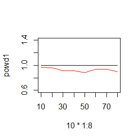

```r
plot(10*1:8,powd1,type="l")
lines(10*1:8,powb1,col="red")
```

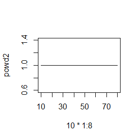

```r
plot(10*1:8,powd2,type="l")
lines(10*1:8,powb2,col="red")
```

homework-2019-11-29

```r
library(GeneralizedHyperbolic)
sigma=c(0.125,0.25,0.5,1,2,4,8)              #the variances we choose
N<-2000                                  #sample size
x0<-25
rw.Metropolis <- function( sigma, x0, N) {
x <- numeric(N)
x[1] <- x0
u <- runif(N)
k <- 0
for (i in 2:N) {
y <- rnorm(1, x[i-1], sigma)
if (u[i] <= exp(-abs(y)) / exp(-abs(x[i-1]))  ){
x[i] <- y
}
else {
x[i] <- x[i-1]
k <- k + 1
}
}
return(list(x=x, k=k))
}
rw1 <- rw.Metropolis( sigma[1], x0, N)
rw2 <- rw.Metropolis( sigma[2], x0, N)
rw3 <- rw.Metropolis( sigma[3], x0, N)
rw4 <- rw.Metropolis( sigma[4], x0, N)
rw5 <- rw.Metropolis( sigma[5], x0, N)
rw6 <- rw.Metropolis( sigma[6], x0, N)
rw7 <- rw.Metropolis( sigma[7], x0, N)
print(c(rw1$k, rw2$k, rw3$k, rw4$k,rw5$k,rw6$k,rw7$k))      #the acceptance rates
```

```
## [1]   96  176  319  555  966 1352 1570
```

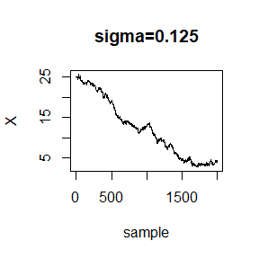

```r
plot(1:N,rw1$x,type="l",xlab="sample",ylab="X",main="sigma=0.125")    #the chains generated
```

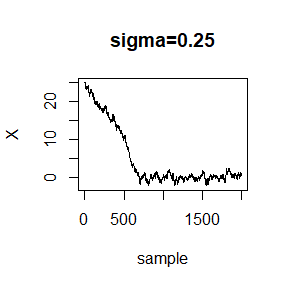

```r
plot(1:N,rw2$x,type="l",xlab="sample",ylab="X",main="sigma=0.25")
```

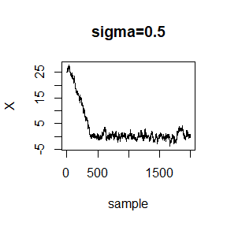

```r
plot(1:N,rw3$x,type="l",xlab="sample",ylab="X",main="sigma=0.5")
```

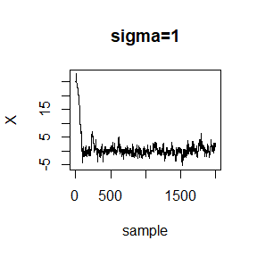

```r
plot(1:N,rw4$x,type="l",xlab="sample",ylab="X",main="sigma=1")
```